### ggplot2

The functionality we’ve shown you so far is all included with R by default. (And it’s pretty powerful, isn’t it?) But in case the default installation doesn’t include that function you need, there are still more libraries available on the servers of the Comprehensive R Archive Network, or CRAN. They can add anything from new statistical functions to better graphics capabilities. Better yet, installing any of them is just a command away.

Let’s install the popular **ggplot2** graphics package. Call the **install.packages** function with the package name in a string:

```r
install.packages("ggplot2")
```

You can get help for a package by calling the help function and passing the package name in the package argument. Try displaying help for the “ggplot2” package:

```r
help(package = "ggplot2")
```

Here’s a quick demo of the power you’ve just added to R. To use it, let’s revisit some data from a previous chapter.

```r
weights <- c(300, 200, 100, 250, 150)
prices <- c(9000, 5000, 12000, 7500, 18000)
chests <- c('gold', 'silver', 'gems', 'gold', 'gems')
types <- factor(chests)
```

The qplot function is a commonly-used part of ggplot2. We’ll pass the weights and values of our cargo to it, using the chest types vector for the color argument:

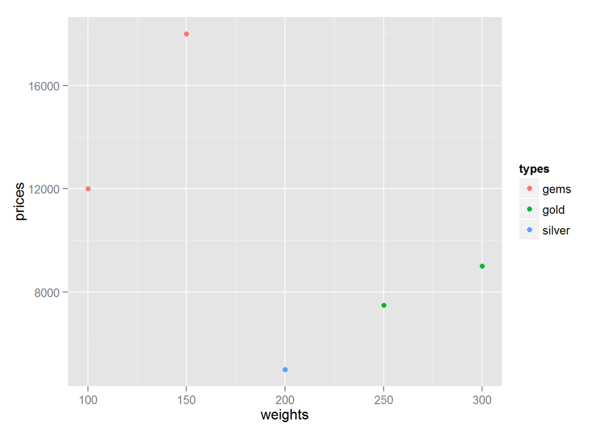

```r
library(ggplot2)
qplot(weights, prices, color = types)
```